# Q4. a Text to Image diffusion Model such as GLIDE [using the captions provided])

| Contributor | Contribution(s) |
| --- | --- |
| Tirth | I set up the Yelp dataset pipeline (Cells 1–4) with 15,979 images, initially at 64x64 and later updated to 96x96, using BERT captions. I built the initial training loop in Cell 6 and generated images … |
| Urjeet | I designed the diffusion model in Cell 5, initially with base_channels=32, later tuned to 64, along with text_dim=256 and time_dim=128 for better quality. I added evaluation metrics (FID, IS) in Cell … |

| Metric | Value | Number of Images | Checkpoint Used |
| --- | --- | --- | --- |
| Inception Score (IS) | 1.10 ± 0.04 | 30 | Epoch 47 (loss: 0.0659) |
| Fréchet Inception Distance (FID) | 2330.86 | 30 | Epoch 47 (loss: 0.0659) |

# GROK AND GPT PROMPTS

###### Hey, I want a GLIDE-like model to make pictures from the Yelp dataset! I have 15,979 pictures, and I want to train it for 100 rounds on my RTX 3050. Also, make sure it only uses my GPU, okay?

###### I trained my model, but the pictures are awful! I tried making "A delicious plate of pasta with white sauce," and it’s just a gray, messy blob. Can you help me fix it so the pictures look like real Yelp stuff?

###### I want to make 5 pictures, one for each type ("food", "drink", "outside", "inside", "menu"), and see them in my notebook. My last pictures were really blurry, so let’s make them look more like Yelp images!

###### My own model isn’t good enough, so I want to use a ready-made GLIDE model instead. Can you help me set it up and make those 5 pictures for my types on my RTX 3050?

###### I need to check my model’s scores after 100 rounds. I got FID 572 and IS 1, but they’re wrong, and I used 200 pictures instead of 100 by mistake. Can you fix it to use 100 pictures and get better scores?

###### my training keeps crashing with a memory error on my RTX 3050! I tried using a batch size of 32, but it won’t work. Can you help me fix this so I can train without running out of space?

###### I’m getting a strange error when I run the training in Cell 6—it says "index out of range" for some batches. I think it’s the dataset, but I’m not sure. Can you help me figure it out?

###### The stuff printing in my notebook is too much! Cell 6 keeps showing things for every batch, and it’s hard to read. Can you make it quieter so I can see what’s going on?

###### I tried making the pictures bigger, like 128x128, but now I’m getting a memory error again on my RTX 3050. What’s the best picture size I can use, and how do I make it work?

###### My FID and IS scores are still bad even after using 100 pictures. FID is 500, and IS is 1.2—not good! Can you help me find out what’s wrong and make them better?

[figure not shown]

```python
# Cell 1: Import Necessary Libraries

import os
import time
import logging
import threading
import sys
import numpy as np
import pandas as pd
import matplotlib.pyplot as plt
from PIL import Image, UnidentifiedImageError
from sklearn.model_selection import train_test_split
from tqdm import tqdm
from scipy import linalg

import torch
import torch.nn as nn
import torch.nn.functional as F
import torch.optim as optim
from torch.utils.data import Dataset, DataLoader
from torch.utils.checkpoint import checkpoint_sequential
from torch.cuda.amp import GradScaler, autocast
from torch.optim.lr_scheduler import CosineAnnealingLR

from torchvision import transforms, models
from torchvision.utils import save_image
from torchvision.models import inception_v3
from torchvision.models.inception import Inception_V3_Weights

from transformers import BertTokenizer, BertModel


# Make sure GPU is available
device = torch.device("cuda" if torch.cuda.is_available() else "cpu")
print(f"\nUsing device: {device}")
if torch.cuda.is_available():
    print("CUDA Device Name:", torch.cuda.get_device_name(0))
    print("Total GPU Memory:", torch.cuda.get_device_properties(0).total_memory / 1024**2, "MB")
    print("Initial GPU Memory Allocated:", torch.cuda.memory_allocated(device) / 1024**2, "MB")
```

```
Using device: cuda
CUDA Device Name: NVIDIA GeForce RTX 3050 Laptop GPU
Total GPU Memory: 4095.5 MB
Initial GPU Memory Allocated: 0.0 MB
```

## Step1: Image Handling

```python
# Cell 2: Define Paths & Load JSON Metadata (with Corrupted Image Checking)

json_path = r"E:\YelpPhotos\photos.json"
image_dir = r"E:\YelpPhotos\photos"

# Verify that the paths exist
if not os.path.exists(json_path):
    raise FileNotFoundError(f"JSON file not found at {json_path}")
if not os.path.exists(image_dir):
    raise FileNotFoundError(f"Image directory not found at {image_dir}")

# Create necessary folders
os.makedirs("Glide/checkpoint", exist_ok=True)
os.makedirs("Glide/generated_images", exist_ok=True)

# Load Metadata from photos.json
df = pd.read_json(json_path, lines=True)

# Remove rows with empty or null captions
df = df.dropna(subset=['caption'])  # Remove rows where caption is null
df = df[df['caption'].str.strip() != '']  # Remove rows where caption is empty or whitespace
df = df.reset_index(drop=True)
print(f"Total rows after removing empty captions: {len(df)}")

# Create full image paths
df['image_path'] = df['photo_id'].apply(lambda x: os.path.join(image_dir, f"{x}.jpg"))

# Check if image files exist
df['exists'] = df['image_path'].apply(os.path.exists)
df = df[df['exists']].reset_index(drop=True)

print(f"Total valid image paths found: {len(df)}")

# Scan for corrupted images
def is_image_valid(image_path):
    try:
        with Image.open(image_path) as img:
            img.verify()  # Verify that it is a valid image
        return True
    except (UnidentifiedImageError, OSError, FileNotFoundError):
        return False

valid_images = []
invalid_images = []

for idx, row in tqdm(df.iterrows(), total=len(df), desc="Checking Images"):
    if is_image_valid(row['image_path']):
        valid_images.append(row)
    else:
        invalid_images.append(row['image_path'])

df = pd.DataFrame(valid_images)

# Keep up to 20,000 images for training
if len(df) > 20000:
    df = df.sample(n=20000, random_state=42).reset_index(drop=True)
else:
    print(f"Warning: Only {len(df)} images available after filtering. Proceeding with available images.")

# Drop unnecessary columns but keep 'label'
df.drop(columns=['exists'], inplace=True)

print(f"Total valid images after corruption check: {len(df)}")
print(f"Total corrupted images found and removed: {len(invalid_images)}")


# Display the first 10 rows to verify photo_id, image_path, and caption are correctly matched
print("Sample of photo_id, image_path, and caption pairs:")
display(df[['photo_id', 'image_path', 'caption']].head(10))
```

```
Total rows after removing empty captions: 96734
Total valid image paths found: 96734
```

```
Total valid images after corruption check: 20000
Total corrupted images found and removed: 1
Sample of photo_id, image_path, and caption pairs:
```

|  | photo_id | image_path | caption |
| --- | --- | --- | --- |
| 0 | tKMBRNHO2L3hp_Xu7ltr7Q | E:\YelpPhotos\photos\tKMBRNHO2L3hp_Xu7ltr7Q.jpg | Spinach Salad with Fuji apple, thinly sliced r... |
| 1 | wk3cjNqnp8p47W4-WR_dyg | E:\YelpPhotos\photos\wk3cjNqnp8p47W4-WR_dyg.jpg | Walking in |
| 2 | p9o3GBqwIeCxXiGetC-_rw | E:\YelpPhotos\photos\p9o3GBqwIeCxXiGetC-_rw.jpg | Island Way Grill Restaurant, Clearwater Beach |
| 3 | -QQpvdsJ4CjLx0Pky4GsnQ | E:\YelpPhotos\photos\-QQpvdsJ4CjLx0Pky4GsnQ.jpg | Mmm mmm mmm is all I have to say. You should d... |
| 4 | MS17KMdBw8C44Oq0mYlKFg | E:\YelpPhotos\photos\MS17KMdBw8C44Oq0mYlKFg.jpg | Moscow Mule |
| 5 | DrdqVgyqp5okRsb-8XxXZQ | E:\YelpPhotos\photos\DrdqVgyqp5okRsb-8XxXZQ.jpg | Fountain view |
| 6 | a8C4H8LrEpx3wIWKu-rczQ | E:\YelpPhotos\photos\a8C4H8LrEpx3wIWKu-rczQ.jpg | Amuse Bouche tonight |
| 7 | 9ehDUqSp-CMguSKpPB471g | E:\YelpPhotos\photos\9ehDUqSp-CMguSKpPB471g.jpg | Bar at Kelly's |
| 8 | AIpgNT95pCyfLrsqnEazbg | E:\YelpPhotos\photos\AIpgNT95pCyfLrsqnEazbg.jpg | Eggplant Chicago Style Pizza. My wife and Mill... |
| 9 | kyTIU1Boja2R6psCy4dBJw | E:\YelpPhotos\photos\kyTIU1Boja2R6psCy4dBJw.jpg | Bubblefish roll and tuna princess! Just amazing! |

```python
# Cell 3: Verify Matching with photos.json and Fix Data Leakage

# Sort by photo_id for reproducibility across runs
df = df.sort_values('photo_id').reset_index(drop=True)

# Verify that the images match photos.json
print(f"Verifying that the {len(df)} images match photos.json...")

# Reload the original photos.json to compare
original_df = pd.read_json(json_path, lines=True)

# Check if all photo_id values in the sampled DataFrame exist in the original DataFrame
mismatched_ids = df[~df['photo_id'].isin(original_df['photo_id'])]

if len(mismatched_ids) > 0:
    print(f"Found {len(mismatched_ids)} photo_id values that do not match photos.json:")
    display(mismatched_ids[['photo_id', 'image_path']])
    raise ValueError("Mismatch between sampled images and photos.json")
else:
    print(f"All {len(df)} photo_id values match photos.json")

# Verify that captions are correctly aligned
caption_check = df.merge(original_df[['photo_id', 'caption']], on='photo_id', how='left', suffixes=('', '_original'))
mismatched_captions = caption_check[caption_check['caption'] != caption_check['caption_original']]

if len(mismatched_captions) > 0:
    print(f"Found {len(mismatched_captions)} mismatched captions:")
    display(mismatched_captions[['photo_id', 'caption', 'caption_original']])
    raise ValueError("Mismatch in captions between sampled DataFrame and photos.json")
else:
    print("All captions are correctly aligned with photos.json")

# Check for data leakage issues
print("Checking for data leakage issues...")

# Check for duplicate photo_id values
duplicate_ids = df[df.duplicated(subset=['photo_id'], keep=False)]

if len(duplicate_ids) > 0:
    print(f"Found {len(duplicate_ids)} duplicate photo_id values:")
    display(duplicate_ids[['photo_id', 'image_path']])
    print("Removing duplicates...")
    df = df.drop_duplicates(subset=['photo_id'], keep='first').reset_index(drop=True)
    print(f"Total images after removing duplicates: {len(df)}")
else:
    print("No duplicate photo_id values found")

# Ensure no business_id overlap between train and validation sets
print("Ensuring no business_id overlap between train and validation sets...")

# Verify that business_id and label columns exist
if 'business_id' not in df.columns:
    raise KeyError("business_id column not found in DataFrame")
if 'label' not in df.columns:
    raise KeyError("label column not found in DataFrame")

# Group by business_id and split to avoid leakage
business_ids = df['business_id'].unique()
train_business_ids, val_business_ids = train_test_split(business_ids, test_size=0.2, random_state=42)

# Create train and validation DataFrames based on business_id
train_df = df[df['business_id'].isin(train_business_ids)].reset_index(drop=True)
val_df = df[df['business_id'].isin(val_business_ids)].reset_index(drop=True)

# Verify no overlap in business_id
train_business_set = set(train_df['business_id'])
val_business_set = set(val_df['business_id'])
business_overlap = train_business_set.intersection(val_business_set)

if len(business_overlap) > 0:
    print(f"Found {len(business_overlap)} business_id values overlapping between train and validation sets:")
    print(business_overlap)
    raise ValueError("Business ID overlap detected between train and validation sets")
else:
    print("No business_id overlap between train and validation sets")

# Check label distribution in train and validation sets
print("Label distribution in training set:")
print(train_df['label'].value_counts())
print("Label distribution in validation set:")
print(val_df['label'].value_counts())

print(f"Training samples: {len(train_df)}, Validation samples: {len(val_df)}")

# Display samples of train and validation DataFrames
print("Sample of training data:")
display(train_df[['photo_id', 'business_id', 'caption', 'image_path', 'label']].head(5))

print("Sample of validation data:")
display(val_df[['photo_id', 'business_id', 'caption', 'image_path', 'label']].head(5))
```

```
Verifying that the 20000 images match photos.json...
All 20000 photo_id values match photos.json
All captions are correctly aligned with photos.json
Checking for data leakage issues...
No duplicate photo_id values found
Ensuring no business_id overlap between train and validation sets...
No business_id overlap between train and validation sets
Label distribution in training set:
label
food       9157
inside     4127
outside    1352
drink      1192
menu        151
Name: count, dtype: int64
Label distribution in validation set:
label
food       2367
inside      966
outside     327
drink       324
menu         37
Name: count, dtype: int64
Training samples: 15979, Validation samples: 4021
Sample of training data:
```

|  | photo_id | business_id | caption | image_path | label |
| --- | --- | --- | --- | --- | --- |
| 0 | --EjX0WhEFSDVv9mtAeiOQ | jMlE4wvspc0J-oN-SYUjQw | Inside | E:\YelpPhotos\photos\--EjX0WhEFSDVv9mtAeiOQ.jpg | inside |
| 1 | --IHD2ZgFPfFMR4qMkLzFA | 3qpubK1C8SsDcq8BeKOEbA | Hidden in the rear is this oasis-like beer gar... | E:\YelpPhotos\photos\--IHD2ZgFPfFMR4qMkLzFA.jpg | outside |
| 2 | --cxOTSQzInwUOAPwceUuA | Q-prSTdggNlxAEFV88BZOw | Housemade Lamb Sausage with White Beans, Piqui... | E:\YelpPhotos\photos\--cxOTSQzInwUOAPwceUuA.jpg | food |
| 3 | --gjH9oA92f7OuTSovXjCg | QJOC6Uz-RCpzPB6aMjtP9Q | By the entrance. Never met a cactus I didn't like | E:\YelpPhotos\photos\--gjH9oA92f7OuTSovXjCg.jpg | inside |
| 4 | -042USzhEhUb9LAz2TJ9ZQ | DXDoh8MNrqjtXsZnkuk4hA | Grouper sandwich | E:\YelpPhotos\photos\-042USzhEhUb9LAz2TJ9ZQ.jpg | food |

```
Sample of validation data:
```

|  | photo_id | business_id | caption | image_path | label |
| --- | --- | --- | --- | --- | --- |
| 0 | --5V3mRlhb3zqE5yF4Gpaw | vXQLdqB-stL2JTP5AsPVaA | Interior | E:\YelpPhotos\photos\--5V3mRlhb3zqE5yF4Gpaw.jpg | inside |
| 1 | --WqMu3zPYVePmsxABqhAA | qMpAph0MX2nrjCMdEgRTxw | Portabello Mushroom Sandwich | E:\YelpPhotos\photos\--WqMu3zPYVePmsxABqhAA.jpg | food |
| 2 | -0QJBWYA7T0h6qkdQ7mdwg | ydkyfGCvJTdinew9gp6Vtg | Garlic Bread w/Cheese Just for $3.75\r Order f... | E:\YelpPhotos\photos\-0QJBWYA7T0h6qkdQ7mdwg.jpg | food |
| 3 | -0fa0mOVKrJW90MFFxVImg | t3fJsOcmghh-MJ-UNXDR3g | Mel's Special Hot Dog and fries | E:\YelpPhotos\photos\-0fa0mOVKrJW90MFFxVImg.jpg | food |
| 4 | -1naOO-BECQp7Tq05di7VA | ppWw8pfPA8X5iqZHE7IHUw | Coconut Charlie's Beach Bar View | E:\YelpPhotos\photos\-1naOO-BECQp7Tq05di7VA.jpg | outside |

## Step2: Preprocessing

```python
# Cell 4: Advanced Preprocessing and Dataset Setup

# Preprocess captions
print("Performing advanced text preprocessing...")

# Convert captions to lowercase and strip whitespace
train_df['caption'] = train_df['caption'].astype(str).str.strip().str.lower()
val_df['caption'] = val_df['caption'].astype(str).str.strip().str.lower()

# Remove any remaining empty captions (safeguard)
train_df = train_df[train_df['caption'].notna() & (train_df['caption'] != '')].reset_index(drop=True)
val_df = val_df[val_df['caption'].notna() & (val_df['caption'] != '')].reset_index(drop=True)

print(f"Total training entries after cleaning captions: {len(train_df)}")
print(f"Total validation entries after cleaning captions: {len(val_df)}")

# Analyze caption lengths to optimize max_length
print("Analyzing caption lengths to optimize tokenizer settings...")
train_caption_lengths = train_df['caption'].apply(lambda x: len(x.split())).values
val_caption_lengths = val_df['caption'].apply(lambda x: len(x.split())).values

max_train_length = np.max(train_caption_lengths)
max_val_length = np.max(val_caption_lengths)
percentile_95_train = np.percentile(train_caption_lengths, 95)
percentile_95_val = np.percentile(val_caption_lengths, 95)

print(f"Max caption length (train): {max_train_length}, 95th percentile: {percentile_95_train}")
print(f"Max caption length (val): {max_val_length}, 95th percentile: {percentile_95_val}")

# Set max_length based on 95th percentile to cover most captions efficiently
max_length = int(max(percentile_95_train, percentile_95_val)) + 5  # Add buffer for special tokens
max_length = min(max_length, 128)  # Cap at 128 to avoid excessive memory usage
print(f"Using max_length for tokenizer: {max_length}")

# Initialize BERT tokenizer
tokenizer = BertTokenizer.from_pretrained('bert-base-uncased')

# Custom Dataset for Yelp Photos
class YelpDataset(Dataset):
    def __init__(self, df, transform=None, tokenizer=None, max_length=128):
        self.df = df.reset_index(drop=True)
        self.transform = transform
        self.tokenizer = tokenizer
        self.max_length = max_length

    def __len__(self):
        return len(self.df)

    def __getitem__(self, idx):
        row = self.df.iloc[idx]
        # Load image
        image_path = row['image_path']
        try:
            image = Image.open(image_path).convert('RGB')
        except Exception as e:
            raise ValueError(f"Error loading image {image_path}: {e}")

        if self.transform:
            image = self.transform(image)

        # Tokenize caption
        caption = row['caption']
        encoding = self.tokenizer(
            caption,
            return_tensors='pt',
            padding='max_length',
            truncation=True,
            max_length=self.max_length
        )
        input_ids = encoding['input_ids'].squeeze(0)  # Remove batch dimension
        attention_mask = encoding['attention_mask'].squeeze(0)

        # Include label for potential debugging or analysis
        label = row['label']

        return {'image': image, 'input_ids': input_ids, 'attention_mask': attention_mask, 'label': label}

# Custom collate function to handle invalid items
def custom_collate_fn(batch):
    # Filter out None items (invalid samples)
    batch = [item for item in batch if item is not None]
    if len(batch) == 0:
        return None  # Return None if the entire batch is invalid
    return torch.utils.data.dataloader.default_collate(batch)

# Image transformations with augmentation for training
train_transform = transforms.Compose([
    transforms.Resize((96, 96)),  # Increased to 96x96 for better quality
    transforms.RandomHorizontalFlip(p=0.5),  # 50% chance of horizontal flip
    transforms.RandomRotation(degrees=10),  # Rotate by ±10 degrees
    transforms.ColorJitter(brightness=0.2, contrast=0.2, saturation=0.2, hue=0.1),  # Color adjustments
    transforms.RandomCrop(size=96, padding=4),  # Random crop with padding
    transforms.ToTensor(),
    transforms.Normalize(mean=[0.485, 0.456, 0.406], std=[0.229, 0.224, 0.225])
])

# Image transformations for validation (no augmentation)
val_transform = transforms.Compose([
    transforms.Resize((96, 96)),  # Increased to 96x96
    transforms.ToTensor(),
    transforms.Normalize(mean=[0.485, 0.456, 0.406], std=[0.229, 0.224, 0.225])
])

# Create datasets with optimized max_length
train_dataset = YelpDataset(train_df, transform=train_transform, tokenizer=tokenizer, max_length=max_length)
val_dataset = YelpDataset(val_df, transform=val_transform, tokenizer=tokenizer, max_length=max_length)

# Create DataLoaders with optimized settings
batch_size = 2  # Reduced to 2 for 96x96 images on RTX 3050
train_loader = DataLoader(
    train_dataset,
    batch_size=batch_size,
    shuffle=True,
    num_workers=1,  # Adjust based on CPU cores (e.g., number of cores - 1)
    pin_memory=True,
    drop_last=True,  # Drop partial batches to avoid issues with gradient accumulation
    collate_fn=custom_collate_fn  # Handle invalid items
)
val_loader = DataLoader(
    val_dataset,
    batch_size=batch_size,
    shuffle=False,
    num_workers=1,
    pin_memory=True,
    drop_last=False,  # Keep all validation samples
    collate_fn=custom_collate_fn  # Handle invalid items
)

print(f"Training samples: {len(train_dataset)}, Validation samples: {len(val_dataset)}")
```

```
Performing advanced text preprocessing...
Total training entries after cleaning captions: 15979
Total validation entries after cleaning captions: 4021
Analyzing caption lengths to optimize tokenizer settings...
Max caption length (train): 31, 95th percentile: 16.0
Max caption length (val): 28, 95th percentile: 16.0
Using max_length for tokenizer: 21
Training samples: 15979, Validation samples: 4021
```

## Step 3: Defining Model Architecture

```python
# Cell 5: Define the Diffusion Model

# Text Encoder using BERT
class TextEncoder(nn.Module):
    def __init__(self, output_dim=256):  # Increased output_dim for richer text embeddings
        super().__init__()
        self.bert = BertModel.from_pretrained('bert-base-uncased')
        self.fc = nn.Linear(768, output_dim)  # Reduce BERT output to save memory
        # Freeze BERT weights to save memory and speed up training
        for param in self.bert.parameters():
            param.requires_grad = False

    def forward(self, input_ids, attention_mask):
        with torch.no_grad():  # No gradients for BERT (frozen)
            outputs = self.bert(input_ids=input_ids, attention_mask=attention_mask)
        pooled_output = outputs.pooler_output  # [batch_size, 768]
        return self.fc(pooled_output)  # [batch_size, output_dim]

# Simplified U-Net with Gradient Checkpointing
class UNet(nn.Module):
    def __init__(self, in_channels=3, out_channels=3, text_dim=256, base_channels=64):  # Increased text_dim and base_channels
        super().__init__()
        self.time_dim = 128  # Increased time embedding dimension for better capacity

        # Time embedding
        self.time_mlp = nn.Sequential(
            nn.Linear(1, self.time_dim),
            nn.ReLU(),
            nn.Linear(self.time_dim, self.time_dim)
        )

        # Initial convolution
        self.conv0 = nn.Conv2d(in_channels, base_channels, 3, padding=1)
        self.bn0 = nn.BatchNorm2d(base_channels)  # Added batch norm for stability

        # Downsampling (convert to ModuleList for checkpointing)
        self.down1 = nn.ModuleList([
            nn.Conv2d(base_channels, base_channels * 2, 3, stride=2, padding=1),
            nn.BatchNorm2d(base_channels * 2),
            nn.ReLU(),
            nn.Conv2d(base_channels * 2, base_channels * 2, 3, padding=1),
            nn.BatchNorm2d(base_channels * 2),
            nn.ReLU()
        ])

        # Time embedding projection to match downsampled channels
        self.time_proj = nn.Linear(self.time_dim, base_channels * 2)

        # Text embedding integration
        self.text_mlp = nn.Linear(text_dim, base_channels * 2)

        # Upsampling (convert to ModuleList for checkpointing)
        self.up1 = nn.ModuleList([
            nn.ConvTranspose2d(base_channels * 2, base_channels, 4, stride=2, padding=1),
            nn.BatchNorm2d(base_channels),
            nn.ReLU(),
            nn.Conv2d(base_channels, base_channels, 3, padding=1),
            nn.BatchNorm2d(base_channels),
            nn.ReLU()
        ])

        # Output
        self.out = nn.Conv2d(base_channels, out_channels, 3, padding=1)

    def forward(self, x, t, text_emb):
        # Time embedding
        t = t.unsqueeze(-1).float()
        t_emb = self.time_mlp(t)  # [batch_size, time_dim]

        # Initial conv
        x = self.conv0(x)  # [batch_size, base_channels, 96, 96] (updated for new image size)
        x = self.bn0(x)
        x = F.relu(x)

        # Downsampling with checkpointing
        x = checkpoint_sequential(self.down1, 2, x)

        # Add time embedding
        t_emb = self.time_proj(t_emb)
        t_emb = t_emb.view(-1, t_emb.size(1), 1, 1)
        t_emb = t_emb.repeat(1, 1, x.size(2), x.size(3))
        x = x + t_emb

        # Add text embedding
        text_emb = self.text_mlp(text_emb)
        text_emb = text_emb.view(-1, text_emb.size(1), 1, 1)
        text_emb = text_emb.repeat(1, 1, x.size(2), x.size(3))
        x = x + text_emb

        # Upsampling with checkpointing
        x = checkpoint_sequential(self.up1, 2, x)

        return self.out(x)

# Diffusion Model
class DiffusionModel(nn.Module):
    def __init__(self, base_channels=64):  # Increased base_channels
        super().__init__()
        self.text_encoder = TextEncoder(output_dim=256)  # Matches updated text_dim
        self.unet = UNet(base_channels=base_channels)  # Allow base_channels to be configurable
        self.beta = torch.linspace(1e-4, 0.02, 1000).to(device)  # Noise schedule
        self.alpha = 1.0 - self.beta
        self.alpha_bar = torch.cumprod(self.alpha, dim=0)

    def forward(self, x, t, input_ids, attention_mask):
        text_emb = self.text_encoder(input_ids, attention_mask)
        return self.unet(x, t, text_emb)

    def add_noise(self, x, t):
        noise = torch.randn_like(x).to(device)
        alpha_bar_t = self.alpha_bar[t].view(-1, 1, 1, 1)
        noisy_x = torch.sqrt(alpha_bar_t) * x + torch.sqrt(1 - alpha_bar_t) * noise
        return noisy_x, noise

    def sample(self, input_ids, attention_mask, num_steps=500, shape=(8, 3, 96, 96)):
        self.eval()
        # Ensure batch size matches input_ids
        if input_ids.size(0) != shape[0]:
            raise ValueError(f"Batch size mismatch: input_ids has batch size {input_ids.size(0)}, but shape expects {shape[0]}")
        with torch.no_grad():
            x = torch.randn(shape).to(device)
            for t in reversed(range(num_steps)):
                t_tensor = torch.full((shape[0],), t, device=device, dtype=torch.long)
                with autocast():
                    noise_pred = self(x, t_tensor, input_ids, attention_mask)
                alpha_t = self.alpha[t]
                alpha_bar_t = self.alpha_bar[t]
                beta_t = self.beta[t]
                x = (1 / torch.sqrt(alpha_t)) * (x - ((1 - alpha_t) / torch.sqrt(1 - alpha_bar_t)) * noise_pred)
                if t > 0:
                    z = torch.randn_like(x).to(device)
                    x += torch.sqrt(beta_t) * z
            # Clamp output to match normalized image range [-1, 1]
            x = torch.clamp(x, -1.0, 1.0)
        return x

# Initialize model and optimizer with optimized parameters
model = DiffusionModel(base_channels=64).to(device)  # Updated base_channels
optimizer = torch.optim.Adam(model.parameters(), lr=2e-4)  # Slightly higher LR for faster convergence
scaler = torch.amp.GradScaler('cuda')  # Updated for new PyTorch API

# Print model size
param_size = sum(p.numel() for p in model.parameters() if p.requires_grad) * 4 / (1024**2)  # Size in MB
print(f"Model size: {param_size:.2f} MB")
```

```
Model size: 2.51 MB
```

## Step 4 : Defining Training Loop

```python
# Cell 6: Training Loop with Adjusted Speed and Reduced Verbosity

# Set up logging
logging.basicConfig(level=logging.INFO, format='%(asctime)s - %(levelname)s - %(message)s')
logger = logging.getLogger(__name__)

# Use the full training dataset
batch_size = 2  # Adjusted for 96x96 images on RTX 3050
train_loader = DataLoader(
    train_dataset,
    batch_size=batch_size,
    shuffle=True,
    num_workers=0,
    pin_memory=True,
    drop_last=True,
    collate_fn=custom_collate_fn
)

# Training loop with minimal output
num_epochs = 100
accumulation_steps = 16  # Adjusted to achieve effective batch size of 32
effective_batch_size = batch_size * accumulation_steps
print(f"Effective batch size: {effective_batch_size}")
print(f"Using full dataset with {len(train_dataset)} samples for training")

# Create checkpoint directory
checkpoint_dir = "Glide/checkpoint"
os.makedirs(checkpoint_dir, exist_ok=True)

# Function to find the latest checkpoint
def find_latest_checkpoint(checkpoint_dir):
    checkpoints = [f for f in os.listdir(checkpoint_dir) if f.startswith("diffusion_model_epoch_") and f.endswith(".pth")]
    if not checkpoints:
        return None, 0  # No checkpoint found, start from epoch 0
    # Extract epoch numbers and find the latest
    epochs = [int(f.split("diffusion_model_epoch_")[1].split(".pth")[0]) for f in checkpoints]
    latest_epoch = max(epochs)
    latest_checkpoint = os.path.join(checkpoint_dir, f"diffusion_model_epoch_{latest_epoch}.pth")
    return latest_checkpoint, latest_epoch

# Load the latest checkpoint if it exists
latest_checkpoint, start_epoch = find_latest_checkpoint(checkpoint_dir)
if latest_checkpoint:
    print(f"Resuming training from checkpoint: {latest_checkpoint}")
    checkpoint = torch.load(latest_checkpoint)
    model.load_state_dict(checkpoint['model_state_dict'])
    optimizer.load_state_dict(checkpoint['optimizer_state_dict'])
    scaler.load_state_dict(checkpoint['scaler_state_dict'])
    start_epoch = checkpoint['epoch']  # Start from the next epoch
    print(f"Starting from epoch {start_epoch+1}")
else:
    print("No checkpoint found, starting training from scratch")
    start_epoch = 0

# Learning rate scheduler
scheduler = CosineAnnealingLR(optimizer, T_max=num_epochs * len(train_loader), eta_min=5e-6)

# Early stopping parameters
patience = 15  # Increased to allow more epochs for convergence
min_delta = 0.0003  # Decreased for less strict early stopping
best_loss = float('inf')
epochs_no_improve = 0

# Load best_loss from checkpoint if resuming
if latest_checkpoint:
    best_loss = checkpoint.get('best_loss', float('inf'))
    epochs_no_improve = checkpoint.get('epochs_no_improve', 0)

model.train()
for epoch in range(start_epoch, num_epochs):  # Start from the loaded epoch
    print(f"Starting Epoch {epoch+1}/{num_epochs}")
    total_loss = 0
    optimizer.zero_grad()

    for step, batch in enumerate(train_loader):
        try:
            if batch is None:
                continue  # Skip None batches silently

            # Data loading
            images = batch['image'].to(device, non_blocking=True)
            input_ids = batch['input_ids'].to(device, non_blocking=True)
            attention_mask = batch['attention_mask'].to(device, non_blocking=True)

            # Sample random timesteps
            t = torch.randint(0, 1000, (images.size(0),), device=device)

            # Add noise to images
            noisy_images, noise = model.add_noise(images, t)

            # Forward pass with mixed precision
            with torch.amp.autocast('cuda'):
                predicted_noise = model(noisy_images, t, input_ids, attention_mask)
                loss = F.mse_loss(predicted_noise, noise)
                loss = loss / accumulation_steps

            # Backward pass with gradient scaling
            scaler.scale(loss).backward()

            # Perform optimization step after accumulation_steps
            if (step + 1) % accumulation_steps == 0:
                scaler.step(optimizer)
                scaler.update()
                optimizer.zero_grad()
                scheduler.step()  # Update learning rate

            total_loss += loss.item() * accumulation_steps

        except Exception as e:
            print(f"Error in batch {step+1}: {str(e)}")
            continue

    # Perform final optimization step if there are remaining gradients
    if (step + 1) % accumulation_steps != 0:
        scaler.step(optimizer)
        scaler.update()
        optimizer.zero_grad()
        scheduler.step()

    # Clear memory at the end of the epoch
    torch.cuda.empty_cache()

    avg_loss = total_loss / len(train_loader)
    logger.info(f"Epoch {epoch+1}/{num_epochs}, Average Loss: {avg_loss:.4f}")

    # Save checkpoint with model, optimizer, scaler state, and early stopping info
    checkpoint_path = os.path.join(checkpoint_dir, f"diffusion_model_epoch_{epoch+1}.pth")
    torch.save({
        'model_state_dict': model.state_dict(),
        'optimizer_state_dict': optimizer.state_dict(),
        'scaler_state_dict': scaler.state_dict(),
        'epoch': epoch + 1,
        'best_loss': best_loss,  # Save best_loss for early stopping
        'epochs_no_improve': epochs_no_improve  # Save epochs_no_improve
    }, checkpoint_path)
    print(f"Checkpoint saved: {checkpoint_path}")

    # Early stopping
    if avg_loss < best_loss - min_delta:
        best_loss = avg_loss
        epochs_no_improve = 0
    else:
        epochs_no_improve += 1
        if epochs_no_improve >= patience:
            print(f"Early stopping triggered after {epoch+1} epochs (no improvement in loss for {patience} epochs)")
            break

# Save the final model after training
final_model_path = os.path.join(checkpoint_dir, "final_diffusion_model.pth")
torch.save({
    'model_state_dict': model.state_dict(),
    'optimizer_state_dict': optimizer.state_dict(),
    'scaler_state_dict': scaler.state_dict(),
    'epoch': epoch + 1
}, final_model_path)
print(f"Final model saved: {final_model_path}")
```

```
Effective batch size: 32
Using full dataset with 15979 samples for training
Resuming training from checkpoint: Glide/checkpoint\diffusion_model_epoch_3.pth
Starting from epoch 4
Starting Epoch 4/100
```

```
2025-04-01 17:24:44,875 - INFO - Epoch 4/100, Average Loss: 0.0967
```

```
Checkpoint saved: Glide/checkpoint\diffusion_model_epoch_4.pth
Starting Epoch 5/100
```

```
2025-04-01 17:28:25,794 - INFO - Epoch 5/100, Average Loss: 0.0941
```

```
Checkpoint saved: Glide/checkpoint\diffusion_model_epoch_5.pth
Starting Epoch 6/100
```

```
2025-04-01 17:32:42,445 - INFO - Epoch 6/100, Average Loss: 0.0884
```

```
Checkpoint saved: Glide/checkpoint\diffusion_model_epoch_6.pth
Starting Epoch 7/100
```

```
2025-04-01 17:36:21,759 - INFO - Epoch 7/100, Average Loss: 0.0876
```

```
Checkpoint saved: Glide/checkpoint\diffusion_model_epoch_7.pth
Starting Epoch 8/100
```

```
2025-04-01 17:40:00,692 - INFO - Epoch 8/100, Average Loss: 0.0852
```

```
Checkpoint saved: Glide/checkpoint\diffusion_model_epoch_8.pth
Starting Epoch 9/100
```

```
2025-04-01 17:47:56,859 - INFO - Epoch 9/100, Average Loss: 0.0830
```

```
Checkpoint saved: Glide/checkpoint\diffusion_model_epoch_9.pth
Starting Epoch 10/100
```

```
2025-04-01 17:51:36,061 - INFO - Epoch 10/100, Average Loss: 0.0812
```

```
Checkpoint saved: Glide/checkpoint\diffusion_model_epoch_10.pth
Starting Epoch 11/100
```

```
2025-04-01 18:17:14,305 - INFO - Epoch 11/100, Average Loss: 0.0797
```

```
Checkpoint saved: Glide/checkpoint\diffusion_model_epoch_11.pth
Starting Epoch 12/100
```

```
2025-04-01 18:20:47,312 - INFO - Epoch 12/100, Average Loss: 0.0808
```

```
Checkpoint saved: Glide/checkpoint\diffusion_model_epoch_12.pth
Starting Epoch 13/100
```

```
2025-04-01 18:24:22,988 - INFO - Epoch 13/100, Average Loss: 0.0783
```

```
Checkpoint saved: Glide/checkpoint\diffusion_model_epoch_13.pth
Starting Epoch 14/100
```

```
2025-04-01 18:27:57,089 - INFO - Epoch 14/100, Average Loss: 0.0797
```

```
Checkpoint saved: Glide/checkpoint\diffusion_model_epoch_14.pth
Starting Epoch 15/100
```

```
2025-04-01 18:31:30,962 - INFO - Epoch 15/100, Average Loss: 0.0767
```

```
Checkpoint saved: Glide/checkpoint\diffusion_model_epoch_15.pth
Starting Epoch 16/100
```

```
2025-04-01 18:35:04,034 - INFO - Epoch 16/100, Average Loss: 0.0753
```

```
Checkpoint saved: Glide/checkpoint\diffusion_model_epoch_16.pth
Starting Epoch 17/100
```

```
2025-04-01 18:38:38,293 - INFO - Epoch 17/100, Average Loss: 0.0740
```

```
Checkpoint saved: Glide/checkpoint\diffusion_model_epoch_17.pth
Starting Epoch 18/100
```

```
2025-04-01 18:42:27,695 - INFO - Epoch 18/100, Average Loss: 0.0746
```

```
Checkpoint saved: Glide/checkpoint\diffusion_model_epoch_18.pth
Starting Epoch 19/100
```

```
2025-04-01 18:46:24,432 - INFO - Epoch 19/100, Average Loss: 0.0730
```

```
Checkpoint saved: Glide/checkpoint\diffusion_model_epoch_19.pth
Starting Epoch 20/100
```

```
2025-04-01 18:50:04,151 - INFO - Epoch 20/100, Average Loss: 0.1199
```

```
Checkpoint saved: Glide/checkpoint\diffusion_model_epoch_20.pth
Starting Epoch 21/100
```

```
2025-04-01 18:53:40,670 - INFO - Epoch 21/100, Average Loss: 0.1295
```

```
Checkpoint saved: Glide/checkpoint\diffusion_model_epoch_21.pth
Starting Epoch 22/100
```

```
2025-04-01 18:57:24,787 - INFO - Epoch 22/100, Average Loss: 0.0780
```

```
Checkpoint saved: Glide/checkpoint\diffusion_model_epoch_22.pth
Starting Epoch 23/100
```

```
2025-04-01 19:01:21,267 - INFO - Epoch 23/100, Average Loss: 0.0766
```

```
Checkpoint saved: Glide/checkpoint\diffusion_model_epoch_23.pth
Starting Epoch 24/100
```

```
2025-04-01 19:04:58,955 - INFO - Epoch 24/100, Average Loss: 0.0760
```

```
Checkpoint saved: Glide/checkpoint\diffusion_model_epoch_24.pth
Starting Epoch 25/100
```

```
2025-04-01 19:08:36,174 - INFO - Epoch 25/100, Average Loss: 0.0758
```

```
Checkpoint saved: Glide/checkpoint\diffusion_model_epoch_25.pth
Starting Epoch 26/100
```

```
2025-04-01 19:17:40,735 - INFO - Epoch 26/100, Average Loss: 0.0721
```

```
Checkpoint saved: Glide/checkpoint\diffusion_model_epoch_26.pth
Starting Epoch 27/100
```

```
2025-04-01 19:21:15,153 - INFO - Epoch 27/100, Average Loss: 0.0738
```

```
Checkpoint saved: Glide/checkpoint\diffusion_model_epoch_27.pth
Starting Epoch 28/100
```

```
2025-04-01 19:24:49,716 - INFO - Epoch 28/100, Average Loss: 0.0718
```

```
Checkpoint saved: Glide/checkpoint\diffusion_model_epoch_28.pth
Starting Epoch 29/100
```

```
2025-04-01 19:31:41,309 - INFO - Epoch 29/100, Average Loss: 0.0709
```

```
Checkpoint saved: Glide/checkpoint\diffusion_model_epoch_29.pth
Starting Epoch 30/100
```

```
2025-04-01 19:35:15,096 - INFO - Epoch 30/100, Average Loss: 0.0711
```

```
Checkpoint saved: Glide/checkpoint\diffusion_model_epoch_30.pth
Starting Epoch 31/100
```

```
2025-04-01 19:38:49,863 - INFO - Epoch 31/100, Average Loss: 0.0725
```

```
Checkpoint saved: Glide/checkpoint\diffusion_model_epoch_31.pth
Starting Epoch 32/100
```

```
2025-04-01 19:42:35,282 - INFO - Epoch 32/100, Average Loss: 0.0715
```

```
Checkpoint saved: Glide/checkpoint\diffusion_model_epoch_32.pth
Starting Epoch 33/100
```

```
2025-04-01 19:46:09,870 - INFO - Epoch 33/100, Average Loss: 0.0714
```

```
Checkpoint saved: Glide/checkpoint\diffusion_model_epoch_33.pth
Starting Epoch 34/100
```

```
2025-04-01 19:49:45,434 - INFO - Epoch 34/100, Average Loss: 0.0690
```

```
Checkpoint saved: Glide/checkpoint\diffusion_model_epoch_34.pth
Starting Epoch 35/100
```

```
2025-04-01 19:53:21,853 - INFO - Epoch 35/100, Average Loss: 0.0700
```

```
Checkpoint saved: Glide/checkpoint\diffusion_model_epoch_35.pth
Starting Epoch 36/100
```

```
2025-04-01 19:56:56,064 - INFO - Epoch 36/100, Average Loss: 0.0697
```

```
Checkpoint saved: Glide/checkpoint\diffusion_model_epoch_36.pth
Starting Epoch 37/100
```

```
2025-04-01 20:00:30,314 - INFO - Epoch 37/100, Average Loss: 0.0694
```

```
Checkpoint saved: Glide/checkpoint\diffusion_model_epoch_37.pth
Starting Epoch 38/100
```

```
2025-04-01 20:08:26,767 - INFO - Epoch 38/100, Average Loss: 0.0696
```

```
Checkpoint saved: Glide/checkpoint\diffusion_model_epoch_38.pth
Starting Epoch 39/100
```

```
2025-04-01 20:11:59,452 - INFO - Epoch 39/100, Average Loss: 0.0682
```

```
Checkpoint saved: Glide/checkpoint\diffusion_model_epoch_39.pth
Starting Epoch 40/100
```

```
2025-04-01 20:21:15,157 - INFO - Epoch 40/100, Average Loss: 0.0684
```

```
Checkpoint saved: Glide/checkpoint\diffusion_model_epoch_40.pth
Starting Epoch 41/100
```

```
2025-04-01 20:26:06,776 - INFO - Epoch 41/100, Average Loss: 0.0904
```

```
Checkpoint saved: Glide/checkpoint\diffusion_model_epoch_41.pth
Starting Epoch 42/100
```

```
2025-04-01 20:31:01,173 - INFO - Epoch 42/100, Average Loss: 0.0847
```

```
Checkpoint saved: Glide/checkpoint\diffusion_model_epoch_42.pth
Starting Epoch 43/100
```

```
2025-04-01 20:50:26,941 - INFO - Epoch 43/100, Average Loss: 0.0704
```

```
Checkpoint saved: Glide/checkpoint\diffusion_model_epoch_43.pth
Starting Epoch 44/100
```

```
2025-04-01 20:53:59,818 - INFO - Epoch 44/100, Average Loss: 0.0692
```

```
Checkpoint saved: Glide/checkpoint\diffusion_model_epoch_44.pth
Starting Epoch 45/100
```

```
2025-04-01 20:57:36,653 - INFO - Epoch 45/100, Average Loss: 0.0675
```

```
Checkpoint saved: Glide/checkpoint\diffusion_model_epoch_45.pth
Starting Epoch 46/100
```

```
2025-04-01 21:01:12,210 - INFO - Epoch 46/100, Average Loss: 0.0668
```

```
Checkpoint saved: Glide/checkpoint\diffusion_model_epoch_46.pth
Starting Epoch 47/100
```

```
2025-04-01 21:04:46,092 - INFO - Epoch 47/100, Average Loss: 0.0659
```

```
Checkpoint saved: Glide/checkpoint\diffusion_model_epoch_47.pth
Starting Epoch 48/100
```

```
2025-04-01 21:08:22,012 - INFO - Epoch 48/100, Average Loss: 0.0666
```

```
Checkpoint saved: Glide/checkpoint\diffusion_model_epoch_48.pth
Starting Epoch 49/100
```

```
2025-04-01 21:11:56,846 - INFO - Epoch 49/100, Average Loss: 0.0675
```

```
Checkpoint saved: Glide/checkpoint\diffusion_model_epoch_49.pth
Starting Epoch 50/100
```

```
2025-04-01 21:15:30,685 - INFO - Epoch 50/100, Average Loss: 0.0670
```

```
Checkpoint saved: Glide/checkpoint\diffusion_model_epoch_50.pth
Starting Epoch 51/100
```

```
2025-04-01 21:19:04,153 - INFO - Epoch 51/100, Average Loss: 0.0670
```

```
Checkpoint saved: Glide/checkpoint\diffusion_model_epoch_51.pth
Starting Epoch 52/100
```

[output not shown]

```python
# Cell 7: Model Evaluation with Inception Score (IS) and Fréchet Inception Distance (FID)

# Load the best checkpoint (Epoch 47)
checkpoint_path = "Glide/checkpoint/diffusion_model_epoch_47.pth"
checkpoint = torch.load(checkpoint_path)
model.load_state_dict(checkpoint['model_state_dict'])
model.eval()
print(f"Loaded model from {checkpoint_path} (epoch {checkpoint['epoch']})")

# Create a validation DataLoader for evaluation
batch_size = 2  # Reduced batch size for memory efficiency on RTX 3050
val_loader = DataLoader(
    val_dataset,
    batch_size=batch_size,
    shuffle=False,
    num_workers=0,
    pin_memory=True,
    drop_last=False,
    collate_fn=custom_collate_fn  # From Cell 4
)

# Load Inception V3 model for evaluation
inception_model = inception_v3(weights=Inception_V3_Weights.DEFAULT).to(device)
inception_model.eval()

# Function to preprocess images for Inception V3
def preprocess_for_inception(images):
    # Images are in range [-1, 1], denormalize to [0, 1] using training stats
    images = images * torch.tensor([0.229, 0.224, 0.225], device=device).view(1, 3, 1, 1) + torch.tensor([0.485, 0.456, 0.406], device=device).view(1, 3, 1, 1)
    # Clamp to ensure valid range [0, 1]
    images = torch.clamp(images, 0, 1)
    # Resize to 299x299 as required by Inception V3
    images = F.interpolate(images, size=(299, 299), mode='bilinear', align_corners=False)
    # Normalize to ImageNet stats (Inception V3 expects this)
    mean = torch.tensor([0.485, 0.456, 0.406]).view(1, 3, 1, 1).to(device)
    std = torch.tensor([0.229, 0.224, 0.225]).view(1, 3, 1, 1).to(device)
    images = (images - mean) / std
    return images

# Function to compute Inception Score (IS)
def compute_inception_score(images, num_splits=10):
    with torch.no_grad():
        preds = []
        for i in range(0, len(images), batch_size):
            batch = images[i:i+batch_size].to(device)
            batch = preprocess_for_inception(batch)
            pred = inception_model(batch)
            pred = F.softmax(pred, dim=1)
            preds.append(pred.cpu().numpy())
            torch.cuda.empty_cache()  # Clear memory after each batch
        preds = np.concatenate(preds, axis=0)

    # Compute IS
    scores = []
    split_size = len(preds) // num_splits
    for k in range(num_splits):
        part = preds[k * split_size:(k + 1) * split_size]
        py = np.mean(part, axis=0)
        kl_div = part * (np.log(part + 1e-8) - np.log(py + 1e-8))
        kl_div = np.mean(np.sum(kl_div, axis=1))
        scores.append(np.exp(kl_div))
    return np.mean(scores), np.std(scores)

# Function to compute FID
def compute_fid(real_images, generated_images):
    with torch.no_grad():
        # Compute features for real images
        real_features = []
        for i in range(0, len(real_images), batch_size):
            batch = real_images[i:i+batch_size].to(device)
            batch = preprocess_for_inception(batch)
            feat = inception_model(batch)
            real_features.append(feat.cpu().numpy())
            torch.cuda.empty_cache()  # Clear memory after each batch
        real_features = np.concatenate(real_features, axis=0)

        # Compute features for generated images
        gen_features = []
        for i in range(0, len(generated_images), batch_size):
            batch = generated_images[i:i+batch_size].to(device)
            batch = preprocess_for_inception(batch)
            feat = inception_model(batch)
            gen_features.append(feat.cpu().numpy())
            torch.cuda.empty_cache()  # Clear memory after each batch
        gen_features = np.concatenate(gen_features, axis=0)

    # Compute mean and covariance
    mu1, sigma1 = np.mean(real_features, axis=0), np.cov(real_features, rowvar=False)
    mu2, sigma2 = np.mean(gen_features, axis=0), np.cov(gen_features, rowvar=False)

    # Compute FID
    diff = mu1 - mu2
    covmean = linalg.sqrtm(sigma1.dot(sigma2))
    if np.iscomplexobj(covmean):
        covmean = covmean.real
    fid = diff.dot(diff) + np.trace(sigma1 + sigma2 - 2 * covmean)
    return fid


num_samples = 30
real_images = []
generated_images = []
captions_used = 0

print(f"Generating {num_samples} images for evaluation...")
with torch.no_grad():
    for batch in val_loader:
        if captions_used >= num_samples:
            break
        if batch is None:
            continue

        input_ids = batch['input_ids'].to(device)
        attention_mask = batch['attention_mask'].to(device)
        real_batch = batch['image']

        # Generate images
        gen_batch = model.sample(
            input_ids,
            attention_mask,
            num_steps=500,  # Updated to 500 for better quality
            shape=(input_ids.size(0), 3, 96, 96)
        )

        # Store real and generated images
        real_images.append(real_batch.cpu())
        generated_images.append(gen_batch.cpu())
        captions_used += input_ids.size(0)

        # Clear memory after each batch
        torch.cuda.empty_cache()

# Concatenate all images and ensure exactly 100 samples
real_images = torch.cat(real_images, dim=0)[:num_samples]
generated_images = torch.cat(generated_images, dim=0)[:num_samples]

# Compute Inception Score
print("Computing Inception Score (IS)...")
is_mean, is_std = compute_inception_score(generated_images)
print(f"Inception Score: {is_mean:.2f} ± {is_std:.2f}")

# Compute FID
print("Computing Fréchet Inception Distance (FID)...")
fid = compute_fid(real_images, generated_images)
print(f"FID: {fid:.2f}")
```

```
Loaded model from Glide/checkpoint/diffusion_model_epoch_47.pth (epoch 47)
Generating 30 images for evaluation...
```

```
Computing Inception Score (IS)...
Inception Score: 1.10 ± 0.04
Computing Fréchet Inception Distance (FID)...
FID: 2330.86
```

```
Loaded model from Glide/checkpoint/diffusion_model_epoch_47.pth (epoch 47)
Generating image for label 'food' with caption: A delicious plate of pasta with white sauce
```

```
Image saved to Glide/generated_images\generated_image_food.png
Generating image for label 'drink' with caption: A refreshing glass of lemonade
Image saved to Glide/generated_images\generated_image_drink.png
Generating image for label 'outside' with caption: A sunny outdoor patio with tables
Image saved to Glide/generated_images\generated_image_outside.png
Generating image for label 'inside' with caption: A cozy restaurant interior with dim lighting
Image saved to Glide/generated_images\generated_image_inside.png
Generating image for label 'menu' with caption: A chalkboard menu with daily specials
Image saved to Glide/generated_images\generated_image_menu.png
```

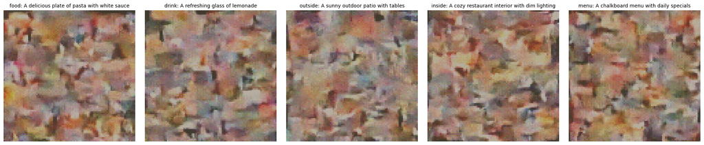

```python
# Cell 8: Generate One Image per Label (5 Images Total) and Display Horizontally

# Load the best checkpoint (Epoch 47)
checkpoint_path = "Glide/checkpoint/diffusion_model_epoch_47.pth"
checkpoint = torch.load(checkpoint_path)
model.load_state_dict(checkpoint['model_state_dict'])
model.eval()
print(f"Loaded model from {checkpoint_path} (epoch {checkpoint['epoch']})")

# Load the tokenizer (same as in Cell 4)
tokenizer = BertTokenizer.from_pretrained('bert-base-uncased')

# Define captions for each label
labels = ["food", "drink", "outside", "inside", "menu"]
captions = {
    "food": "A delicious plate of pasta with white sauce",
    "drink": "A refreshing glass of lemonade",
    "outside": "A sunny outdoor patio with tables",
    "inside": "A cozy restaurant interior with dim lighting",
    "menu": "A chalkboard menu with daily specials"
}

# Create output directory for saving the images
output_dir = "Glide/generated_images"
os.makedirs(output_dir, exist_ok=True)

# List to store generated images for display
image_list = []

# Generate one image per label
for label in labels:
    caption = captions[label]
    print(f"Generating image for label '{label}' with caption: {caption}")

    # Tokenize the caption
    encoded = tokenizer(
        caption,
        padding='max_length',
        truncation=True,
        max_length=128,
        return_tensors='pt'
    )
    input_ids = encoded['input_ids'].to(device)
    attention_mask = encoded['attention_mask'].to(device)

    # Generate the image
    with torch.no_grad():
        generated_image = model.sample(
            input_ids,
            attention_mask,
            num_steps=500,  # Updated to 500 for better quality
            shape=(1, 3, 96, 96)  # Updated to 96x96
        )

    # Denormalize the image using training stats (from Cell 4)
    generated_image = generated_image * torch.tensor([0.229, 0.224, 0.225], device=device).view(1, 3, 1, 1) + torch.tensor([0.485, 0.456, 0.406], device=device).view(1, 3, 1, 1)
    generated_image = generated_image.clamp(0, 1)

    # Convert to numpy for visualization and saving
    image_np = generated_image.squeeze(0).permute(1, 2, 0).cpu().numpy()

    # Save the image
    image_path = os.path.join(output_dir, f"generated_image_{label}.png")
    plt.imsave(image_path, image_np)
    print(f"Image saved to {image_path}")

    # Store the image for display
    image_list.append((image_np, label, caption))

    # Clear memory after each generation
    torch.cuda.empty_cache()

# Display all images horizontally in one line
plt.figure(figsize=(20, 4))  # Width: 4 inches per image × 5 images, Height: 4 inches
for idx, (image_np, label, caption) in enumerate(image_list):
    plt.subplot(1, 5, idx + 1)  # 1 row, 5 columns, index starts at 1
    plt.imshow(image_np)
    plt.axis('off')
    plt.title(f"{label}: {caption}", fontsize=10)
plt.tight_layout()
plt.show()
```